# 11. Cluster Tissues Spatially

Will Hannon

05 October, 2023

The goal of this notebook is to take an unbiased approach to show how similar tissue compartments have similar viral populations. We’ll do this by clustering tissues based on the frequency of SNPs in each sample.

```r
## ==== File paths input data ==== ##

if (exists("snakemake")) {

  # Data from lofreq and varscan labeled with subclonal haplotypes
  updated.data = snakemake@params[["incsv"]]

  # Brain coordinates for plotting spatial heatmap
  brain.coords = snakemake@params[["brain_coords"]]

} else {

  # Data from lofreq and varscan labeled with subclonal haplotypes
  updated.data = "../../results/variants/validated_variants.csv"

  # Brain coordinates for plotting spatial heatmap
  brain.coords = "../../config/brain-coordinates.csv"


}
```

```r
## ==== File paths output data ==== ##

if (exists("snakemake")) {

  # Path to save figures
  figure.dir = paste0(snakemake@params[['figures']], "/")

} else {

  # Path to save figures
  figure.dir ="../../results/figures/"

}

# Make the figure directory if it doesn't exist
if (!file.exists(figure.dir)) {
  dir.create(figure.dir, recursive = TRUE)
  print("Directory created.")
} else {
  print("Directory already exists.")
}
```

```
## [1] "Directory already exists."
```

## Clustering Tissue Samples

First, I do a PCA analysis on the frequency of mutations in each compartment to see if variance in allele frequency between tissues captures any level of spatial information.

```r
# Do the PCA
pcobj = prcomp(frequency.by.snp, center = TRUE, scale. = TRUE)

# PCs to plot
choices = 1:2

# Scaling factors
scale = 1
var.scale = scale
obs.scale = 1 - scale

# Variables for plotting
circle.prob = 0.69
varname.adjust = 1.5
varname.size = 3

# ----------

# Pull the data from the PCA object
nobs.factor = sqrt(nrow(pcobj$x) - 1)
d = pcobj$sdev
u = sweep(pcobj$x, 2, 1 / (d * nobs.factor), FUN = '*')
v = pcobj$rotation

# Scores
choices = pmin(choices, ncol(u))
df.u = as.data.frame(sweep(u[,choices], 2, d[choices]^obs.scale, FUN='*'))

# Directions
v = sweep(v, 2, d^var.scale, FUN='*')
df.v = as.data.frame(v[, choices])

names(df.u)  = c('xvar', 'yvar')
names(df.v) = names(df.u)

df.u = df.u * nobs.factor

# Scale directions
r = sqrt(qchisq(circle.prob, df = 2)) * prod(colMeans(df.u^2))^(1/4)
v.scale = rowSums(v^2)
df.v = r * df.v / sqrt(max(v.scale))

# Append the proportion of explained variance to the axis labels
u.axis.labs = paste('PC', choices, sep='')
u.axis.labs = paste(u.axis.labs,
                    sprintf('(%0.1f%% explained var.)',
                            100 * pcobj$sdev[choices]^2/sum(pcobj$sdev^2)))

# Variables for text label placement
df.v$varname = rownames(v)
df.v$angle = with(df.v, (180/pi) * atan(yvar / xvar))
df.v$hjust = with(df.v, (1 - varname.adjust * sign(xvar)) / 2)

# Add the data from the haplotypes
df.u = df.u %>%
  rownames_to_column(var = "Tissue")

df.v = df.v %>%
  rownames_to_column(var = "SNP") %>%
  left_join(., select(updated.df, SNP, Background, Haplotype, Gene)) %>%
  distinct()
```

First, let’s see what the PCA plot looks like with no loadings superimposed on the plot. The closer the tissues are to each other, the more similar the variant populations.

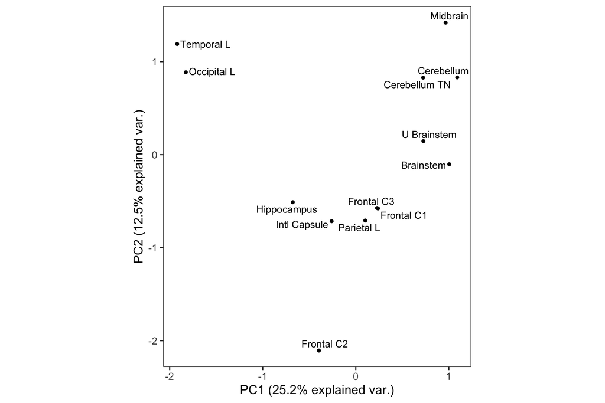

Now, let’s add the loadings to the plot. These are the individual SNPs.

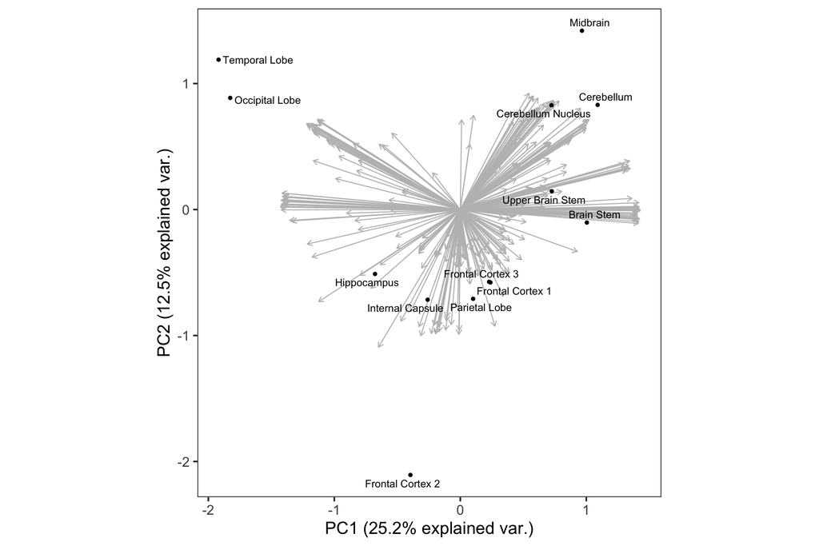

We can see that there are clear groups of SNPs that separate tissues from one another. Let’s see if some of these are explained by the haplotype labels.

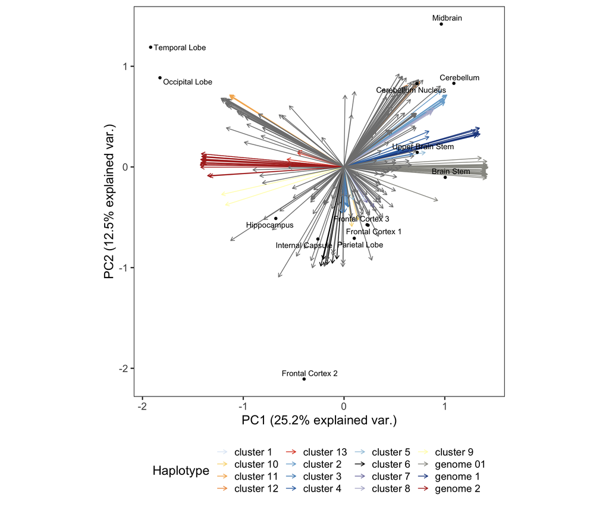

Let’s look at only the haplotype loadings - i.e. the SNPs that we’ve been able to haplotype.

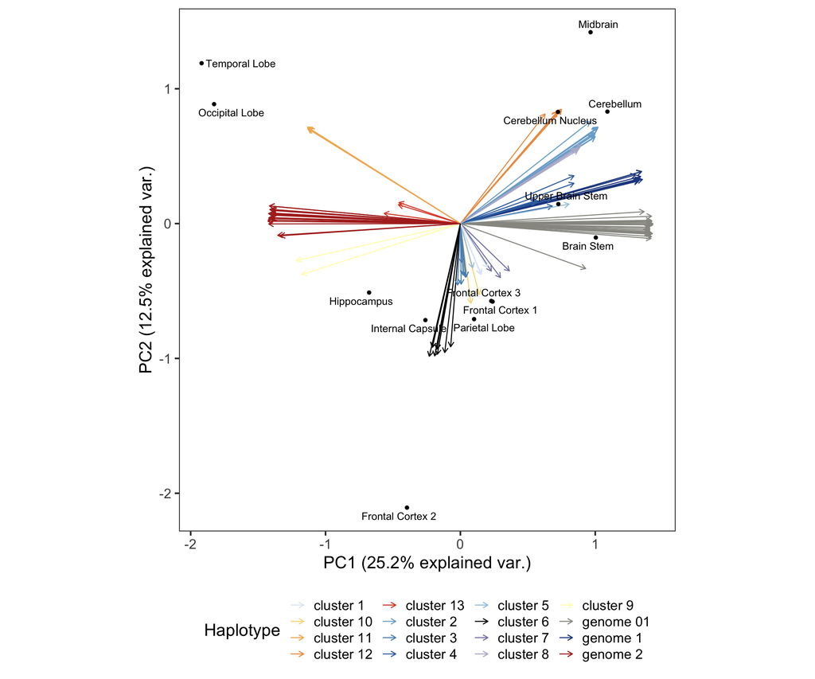

Finally, let’s look at the loadings that are subclonal. Is there some structure that we’ve missed?

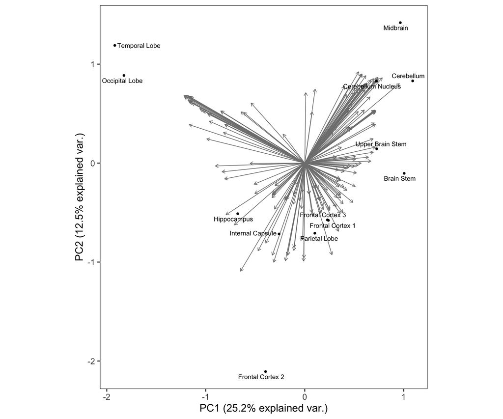

## Haplotypes in Space

Another way of visualizing the distributions of genotypes over space is to plot the fraction of each sample that belongs to a given haplotype. These can be plotted as a pie chart where the centroid of the pie chart is the rough location of the sample in the brain. I’ll make this plot below.

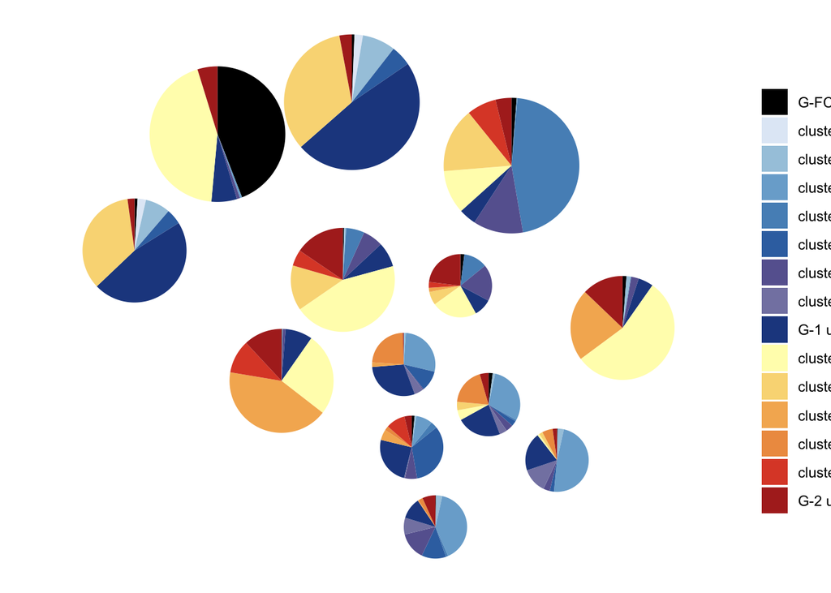